# Experiment 3: ROI Analysis

Above we excluded looks that fell outside the ROIs. In contrast, the original experiment simply coded looks as being to the left or right. This may be more appropriate to the limited resolution of camera-based eye gaze detection. We re-ran analyses based on this split-half coding criterion. The correlation between proportion looks to novel using the ROI method and the halves method is 0.7572099 (see Figure @ref(fig:E3-roi-correlation-of-looking-score)).

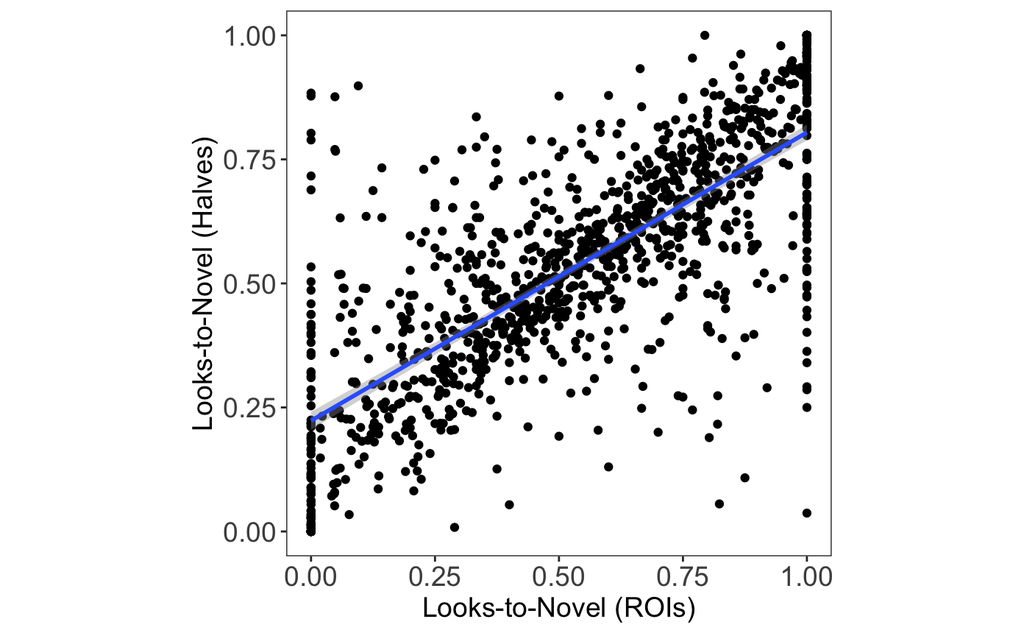

We again found that participants looked more at the novel object, though at a slightly lower rate than before (0.5385341; *SD* = 0.0782987). As before, this was significantly greater than 0.5 (*t*(50) = 3.5145997, *p* < 0.001).

Performance on day 2 remained uncorrelated with day 1 looks-to-novel after switching the coding of gaze. We found no significant different from 0 for the correlation between looks-to-novel and confidence ratings, t(39) = 0.7375769, p = 0.4651864 (excluding the subjects who gave the same confidence judgment for all images), nor the the correlation between looks-to-novel and RT, t(47) = 0.2767609, p = 0.7831772.